# 自然语言处理NLP

### 面授班讲义 by 杨庆跃

请安装最新版本Jupyter notebook进行编程实验

## 目录

- 字符串操作回顾
- NLP原理
- 分词与词性标注
- NLTK简介
- 中文分词包jieba
- 实际操作

```python
s = " hello world "
s.strip()
s.index('o')
s[::-1]
```

```
' dlrow olleh '
```

```python
s = '013245'
print(s[0:3]) #截取第一位到第三位的字符
s.isalpha()
s.isnumeric()
int(s)
```

```
013
```

```
13245
```

### 正则表达式

正则表达式 代表的匹配字符

- [0-9] 0123456789任意之一
- [a-z] 小写字母任意之一
- [A-Z] 大写字母任意之一
- \d 等同于[0-9]
- \D 等同于[^0-9]匹配非数字
- \w 等同于[a-z0-9A-Z_]匹配大小写字母、数字和下划线
- \W 等同于[^a-z0-9A-Z_]等同于上一条取非

正则表达式在线验证工具 http://regexr.com/  
python rem模块使用参考 [这里](https://www.cnblogs.com/tina-python/p/5508402.html)

### python中的正则表达式（re模块）

python rem模块使用参考 [这里](https://www.cnblogs.com/tina-python/p/5508402.html)

#### 主要函数：

- compile()编译正则表达式模式，返回一个对象的模式。（可以把那些常用的正则表达式编译成正则表达式对象，这样可以提高一点效率。） 格式：re.compile(pattern,flags=0)
- search()在字符串内查找模式匹配,只要找到第一个匹配然后返回，如果字符串没有匹配，则返回None。 格式：re.search(pattern, string, flags=0)
- match()决定RE是否在字符串刚开始的位置匹配。
- findall()在字符串中找到正则表达式所匹配的所有子串，并返回一个列表，如果没有找到匹配的，则返回空列表。
- split()按照能够匹配的子串将字符串分割后返回列表
- ……

flags标志含义

- re.S(DOTALL) 使.匹配包括换行在内的所有字符
- re.I（IGNORECASE） 使匹配对大小写不敏感
- re.L（LOCALE） 做本地化识别（locale-aware)匹配，法语等
- re.M(MULTILINE) 多行匹配，影响^和$
- re.X(VERBOSE) 该标志通过给予更灵活的格式以便将正则表达式写得更易于理解
- re.U 根据Unicode字符集解析字符，这个标志影响\w,\W,\b,\B

```python
import re
key = r"admin@73ke.com"
print(re.search("@.+\.",key).group())
```

```
@73ke.
```

```python
import re
key = r"admin@73ke.com"
p1 = r"@.+\."#我想匹配到@后面一直到“.”之间的，在这里是73ke
pattern = re.compile(p1)
print(pattern.findall(key))
```

```
['@73ke.']
```

## NLTK

- NLTK(Natural Language Toolkit) 是一个先进的用于构建处理人类语言数据的python应用的开源平台。
- NLTK官网： http://www.nltk.org
- NLTK素材下载：http://www.nltk.org/nltk_data/

[output not shown]

[output cut: 374 more lines]

```
& : 1
OpenEnterprise : 1
2018User : 1
Group : 1
EventsSpecial : 1
ThanksSocial : 1
media@official_phpCopyright : 1
© : 1
2001-2018 : 1
GroupMy : 1
PHP.netContactOther : 1
PHP.net : 1
sitesMirror : 1
sitesPrivacy : 1
policy : 1
```

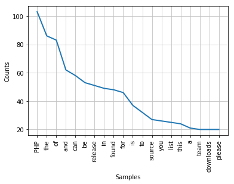

```python
# 没有使用NLTK
from bs4 import BeautifulSoup
import requests
import nltk
%matplotlib inline

html = requests.get("http://www.php.net/")
html.encoding="utf-8"
soup = BeautifulSoup(html.text,"html5lib")
text = soup.get_text(strip=True)
tokens = text.split()
freq = nltk.FreqDist(tokens)
for key,val in freq.items():
 print(key,':',val)

freq.plot(20, cumulative=False)
```

### 使用NLTK切词，加入停用词功能

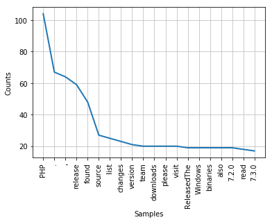

```python
import requests
from nltk.tokenize import word_tokenize
from nltk.corpus import stopwords
html = requests.get('http://www.php.net/')
soup = BeautifulSoup(html.text,"html5lib")
text = soup.get_text(strip=True)
tokens = word_tokenize(text)
clean_tokens = list()
sr = stopwords.words('english')
for token in tokens:
  if not token in sr:
    clean_tokens.append(token)
freq = nltk.FreqDist(clean_tokens)
#for key,val in freq.items():
#  print (str(key) + ':' + str(val))
freq.plot(20, cumulative=False)
```

### 中文分词工具jieba

官方网址https://github.com/fxsjy/jieba

### 中文分词示例

```python
import jieba

seg_list = jieba.cut("我们在湖北学习人工智能课程", cut_all=True)
print(seg_list)
print("全模式: " + "/ ".join(seg_list))  # 全模式

seg_list = jieba.cut("我们在湖北学习人工智能课程", cut_all=False)
print("精确模式: " + "/ ".join(seg_list))  # 精确模式

seg_list = jieba.cut("我们在湖北学习人工智能课程，今后将把人工智能应用于实际工作中")  # 默认是精确模式
print(", ".join(seg_list))

seg_list = jieba.cut_for_search("我们在湖北学习人工智能课程，今后将把人工智能应用于实际工作中")  # 搜索引擎模式
print(", ".join(seg_list))
```

```
Building prefix dict from the default dictionary ...
Loading model from cache C:\Users\Robin\AppData\Local\Temp\jieba.cache
```

```
<generator object Tokenizer.cut at 0x000000000C0C1360>
```

```
Loading model cost 1.158 seconds.
Prefix dict has been built succesfully.
```

```
全模式: 我们/ 在/ 湖北/ 学习/ 人工/ 人工智能/ 智能/ 课程
精确模式: 我们/ 在/ 湖北/ 学习/ 人工智能/ 课程
我们, 在, 湖北, 学习, 人工智能, 课程, ，, 今后, 将, 把, 人工智能, 应用, 于, 实际, 工作, 中
我们, 在, 湖北, 学习, 人工, 智能, 人工智能, 课程, ，, 今后, 将, 把, 人工, 智能, 人工智能, 应用, 于, 实际, 工作, 中
```

#### 使用TF-IDF提取关键词

```python
import jieba.analyse as analyse
#jieba.analyse.set_stop_words('停用词表路径') 可设置停用词表
lines = open('d:/ai/data/19th.txt',encoding = 'utf-8').read()
print("  ".join(analyse.extract_tags(lines, topK=20, withWeight=False, allowPOS=())))
```

```
社会主义  人民  坚持  发展  建设  特色  中国  全面  推进  制度  政治  伟大  体系  实现  加强  国家  社会  时代  中华民族  文化
```

#### 使用TextRank提取关键词

```python
import jieba.analyse as analyse
lines = open('d:/ai/data/19th.txt',encoding='utf-8').read()
print("  ".join(analyse.textrank(lines, topK=20, withWeight=False)))
```

```
发展  中国  建设  人民  社会主义  坚持  制度  国家  推进  社会  特色  全面  加强  政治  体系  文化  实现  完善  经济  时代
```

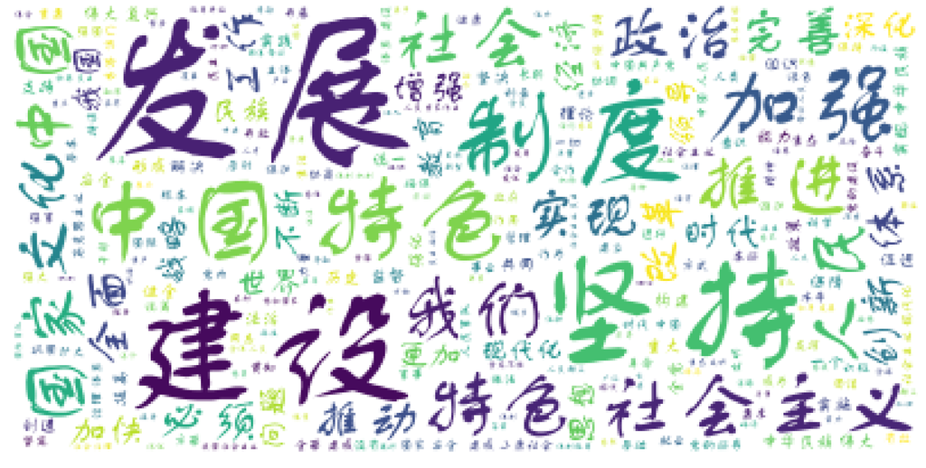

```python
# coding:utf-8
#from os import path
#from scipy.misc import imread
import matplotlib.pyplot as plt
plt.rcParams["font.sans-serif"] = ["SimHei"] #这行和下一行是解决图形标签无法显示中文的问题
plt.rcParams['axes.unicode_minus'] = False

import jieba
from wordcloud import WordCloud, STOPWORDS, ImageColorGenerator

stopwords = {}


def importStopword(filename=''):
    global stopwords
    f = open(filename, 'r', encoding='utf-8')
    line = f.readline().rstrip()

    while line:
        stopwords.setdefault(line, 0)
        stopwords[line] = 1
        line = f.readline().rstrip()
    f.close()


def processChinese(textContent):
    #jieba.enable_parallel(4)
    seg_generator = jieba.cut(textContent)  # 使用结巴分词，也可以不使用
    seg_list = [i for i in seg_generator if i not in stopwords]
    seg_list = [i for i in seg_list if i != u' ']
    seg_list = r' '.join(seg_list)
    return seg_list

# importStopword(filename='./stopwords1.txt')

# 获取当前文件路径
# __file__ 为当前文件, 在ide中运行此行会报错,可改为
# d = path.dirname('.')
# d = path.dirname(__file__)

text = open('d:/ai/data/19th.txt', encoding='utf-8').read()

# 如果是中文
text = processChinese(text)  # 中文不好分词，使用Jieba分词进行

font = r'C:\Windows\Fonts\FZSTK.TTF'

# 设置背景图片

#back_coloring = imread(path.join(d, "./image/nv.png"))

wc = WordCloud(font_path=font,  # 设置字体
               background_color="white",  # 背景颜色
               max_words=2000,  # 词云显示的最大词数
               #mask=back_coloring,  # 设置背景图片
               # max_font_size=100, #字体最大值
               random_state=42,
               )
# 生成词云, 可以用generate输入全部文本(中文不好分词),也可以我们计算好词频后使用generate_from_frequencies函数
wc.generate(text)
# wc.generate_from_frequencies(txt_freq)
# txt_freq例子为[('词a', 100),('词b', 90),('词c', 80)]
# 从背景图片生成颜色值
#image_colors = ImageColorGenerator(back_coloring)
# 绘制词云
plt.figure(figsize=(40,30),dpi=150)
# 以下代码显示图片
plt.imshow(wc)
plt.axis("off")
plt.savefig("d:/ai/data/19th.png",dpi=150)
```

## 词性标注

词性标注（part-of-speech tagging）,又称为词类标注或者简称标注，是指为分词结果中的每个单词标注一个正确的词性的程序，也即确定每个词是名词、动词、形容词或者其他词性的过程。

jieba词性类别如下：

- Ag 形语素 形容词性语素。形容词代码为 a，语素代码ｇ前面置以A。
- a 形容词 取英语形容词 adjective的第1个字母。
- ad 副形词 直接作状语的形容词。形容词代码 a和副词代码d并在一起。
- an 名形词 具有名词功能的形容词。形容词代码 a和名词代码n并在一起。
- b 区别词 取汉字“别”的声母。
- c 连词 取英语连词 conjunction的第1个字母。
- dg 副语素 副词性语素。副词代码为 d，语素代码ｇ前面置以D。
- d 副词 取 adverb的第2个字母，因其第1个字母已用于形容词。
- e 叹词 取英语叹词 exclamation的第1个字母。
- f 方位词 取汉字“方”
- g 语素 绝大多数语素都能作为合成词的“词根”，取汉字“根”的声母。
- h 前接成分 取英语 head的第1个字母。
- i 成语 取英语成语 idiom的第1个字母。
- j 简称略语 取汉字“简”的声母。
- k 后接成分
- l 习用语 习用语尚未成为成语，有点“临时性”，取“临”的声母。
- m 数词 取英语 numeral的第3个字母，n，u已有他用。
- Ng 名语素 名词性语素。名词代码为 n，语素代码ｇ前面置以N。
- n 名词 取英语名词 noun的第1个字母。
- nr 人名 名词代码 n和“人(ren)”的声母并在一起。
- ns 地名 名词代码 n和处所词代码s并在一起。
- nt 机构团体 “团”的声母为 t，名词代码n和t并在一起。
- nz 其他专名 “专”的声母的第 1个字母为z，名词代码n和z并在一起。
- o 拟声词 取英语拟声词 onomatopoeia的第1个字母。
- p 介词 取英语介词 prepositional的第1个字母。
- q 量词 取英语 quantity的第1个字母。
- r 代词 取英语代词 pronoun的第2个字母,因p已用于介词。
- s 处所词 取英语 space的第1个字母。
- tg 时语素 时间词性语素。时间词代码为 t,在语素的代码g前面置以T。
- t 时间词 取英语 time的第1个字母。
- u 助词 取英语助词 auxiliary
- vg 动语素 动词性语素。动词代码为 v。在语素的代码g前面置以V。
- v 动词 取英语动词 verb的第一个字母。
- vd 副动词 直接作状语的动词。动词和副词的代码并在一起。
- vn 名动词 指具有名词功能的动词。动词和名词的代码并在一起。
- w 标点符号
- x 非语素字 非语素字只是一个符号，字母 x通常用于代表未知数、符号。
- y 语气词 取汉字“语”的声母。
- z 状态词 取汉字“状”的声母的前一个字母。
- un 未知词 不可识别词及用户自定义词组。取英文Unkonwn首两个字母。(非北大标准，CSW分词中定义)

```python
import jieba.posseg as pseg
words = pseg.cut("对于这件事我非常愤怒")
for word, flag in words:
    print('%s %s' % (word, flag))
```

```
对于 p
这件 mq
事 n
我 r
非常 d
愤怒 v
```

#### jiaba其他常用功能

jieba.load_userdict(file_name) 载入用户自定义词典

调整词典

- 使用 add_word(word, freq=None, tag=None) 和 del_word(word) 可在程序中动态修改词典。
- 使用 suggest_freq(segment, tune=True) 可调节单个词语的词频，使其能（或不能）被分出来。
- 注意：自动计算的词频在使用 HMM 新词发现功能时可能无效。